# Cue-selection with overt semantic primes

## Experiment

It’s exactly the same as Experiment 1 except that we provide a semantic prime for one of the target words before each critical trial (and we change the words to support this).

[Here](https://memorygame29.herokuapp.com/?skip=6) is a demonstration of the prime. It’s an overt (300ms on screen without mask) semantic prime. I selected stimuli using a free-association dataset, picking targets that were very likely to be produced for given a cue word (the cue becomes our prime). They are not subtle, e.g. “wick” primes “candle”, “teddy” primes “bear”.

Going forward, I think we should probably try to soften the prime, ideally making it subliminal. But I wanted to start by establishing the basic priming effect.

Version(s): v9.0

## Analysis

- Dropping 5 participants with less than 50% accuracy in critical trials
- Dropping error trials
- Z-scoring fixation durations
- 25 participants and 421 trials in the analysis

Note: I’m just plotting raw means here, but the regression is still mixed effects.

# Probability of choosing the primed word

Sanity check.

| Fixed Effects | Fixed Effects Est. | Fixed Effects S.E. | Fixed Effects t val. | Fixed Effects d.f. | Fixed Effects p |
| --- | --- | --- | --- | --- | --- |
| (Intercept) | 0.469 | 0.067 | 7.022 | 24.384 | 0.000 |
| first_primed | 0.338 | 0.087 | 3.891 | 23.478 | 0.001 |

p values calculated using Satterthwaite d.f.

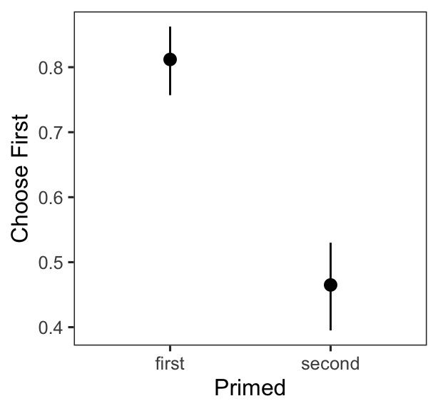

```r
prime_effect = function(data, yvar) {
    data %>%
        mutate(first_primed = int(first_primed)) %>%
        tidylmer(first_primed, {{yvar}}) %>% summ %>% smart_print
    data %>%
        ggplot(aes(primed, {{yvar}})) +
        stat_summary(fun.data=mean_cl_boot) +
        labs(x="Primed", y=pretty_name(ensym(yvar)))
}

human %>%
    filter(n_pres > 0) %>%
    mutate(choose_first = int(choose_first)) %>%
    prime_effect(choose_first)
```

# Overall fixation proportion

```r
human %>%
    filter(n_pres>1) %>%
    prime_effect(prop_first)
```

| Fixed Effects | Fixed Effects Est. | Fixed Effects S.E. | Fixed Effects t val. | Fixed Effects d.f. | Fixed Effects p |
| --- | --- | --- | --- | --- | --- |
| (Intercept) | 0.423 | 0.016 | 25.944 | 262.375 | 0.000 |
| first_primed | 0.116 | 0.031 | 3.688 | 35.856 | 0.001 |

p values calculated using Satterthwaite d.f.

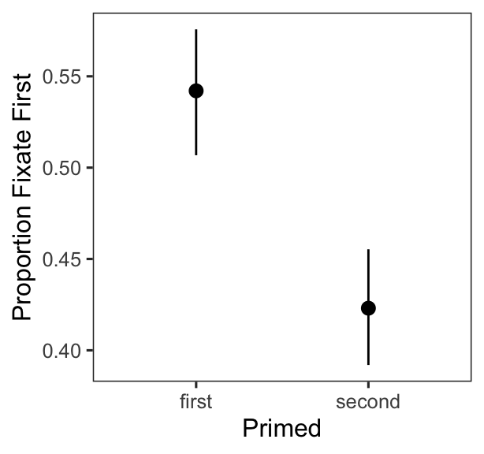

Great!

# Fixation time course

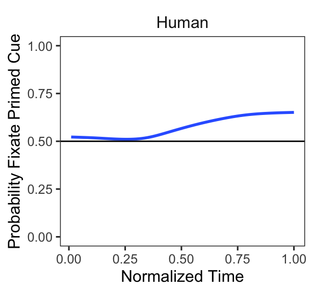

```r
normalized_timestep = function(long) {
    long %>%
        group_by(trial_id) %>%
        # this somewhat complex method ensures that all trials have exactly 100 steps
        # (this isn't true if you just round duration, as I did initially)
        mutate(percentage_complete = round(100*cumsum(duration / sum(duration)))) %>%
        mutate(n_step = diff(c(0, percentage_complete))) %>%
        uncount(n_step) %>%
        group_by(trial_id) %>%
        mutate(normalized_timestep = row_number())
}

long %>%
    filter(name == 'Human') %>%
    left_join(select(human, trial_id, first_primed)) %>%
    mutate(fix_primed = 1*(fix_first == first_primed)) %>%
    normalized_timestep %>%
    drop_na(strength_diff) %>%
    ggplot(aes(normalized_timestep/100, fix_primed)) +
    geom_smooth(se=F) +
    ylim(0, 1) +
    facet_grid(~name) +
    labs(x="Normalized Time", y="Probability Fixate Primed Cue", color="Strength Difference") +
    geom_hline(yintercept=0.5) +
    theme(legend.position="top")
```

Looks good! The point where the curve starts to rise (around 0.3) is a bit later than in Experiment 1.

# Fixation durations

## First fixation

```r
human %>%
    filter(n_pres >= 2) %>%
    prime_effect(first_pres_time)
```

| Fixed Effects | Fixed Effects Est. | Fixed Effects S.E. | Fixed Effects t val. | Fixed Effects d.f. | Fixed Effects p |
| --- | --- | --- | --- | --- | --- |
| (Intercept) | -0.172 | 0.066 | -2.626 | 28.011 | 0.014 |
| first_primed | -0.046 | 0.102 | -0.452 | 16.597 | 0.657 |

p values calculated using Satterthwaite d.f.

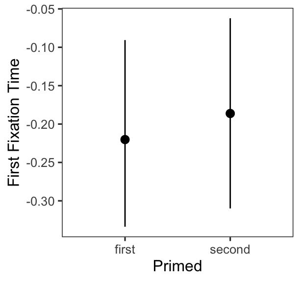

Not surprising, given that it didn’t come out in Experiment 1.

## Second fixation

```r
human %>%
    filter(n_pres >= 3) %>%
    prime_effect(second_pres_time)
```

| Fixed Effects | Fixed Effects Est. | Fixed Effects S.E. | Fixed Effects t val. | Fixed Effects d.f. | Fixed Effects p |
| --- | --- | --- | --- | --- | --- |
| (Intercept) | 0.581 | 0.246 | 2.363 | 11.716 | 0.036 |
| first_primed | -0.373 | 0.259 | -1.438 | 11.289 | 0.178 |

p values calculated using Satterthwaite d.f.

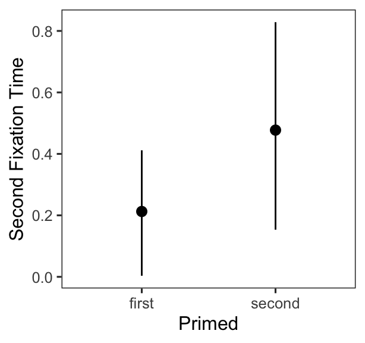

Not significant, but that’s looking pretty good for N=25!

```r
human %>%
    filter(n_pres >= 3) %>%
    mutate(first_primed = int(first_primed)) %>%
    lm(second_pres_time ~ first_primed + strength_first, data=.) %>% summ
```

|  | Est. | S.E. | t val. | p |
| --- | --- | --- | --- | --- |
| (Intercept) | 0.502 | 0.156 | 3.216 | 0.002 |
| first_primed | -0.309 | 0.204 | -1.517 | 0.132 |
| strength_first | -0.062 | 0.101 | -0.619 | 0.537 |

Standard errors: OLS

## Third fixation

```r
human %>%
    filter(n_pres >= 4) %>%
    prime_effect(third_pres_time)
```

| Fixed Effects | Fixed Effects Est. | Fixed Effects S.E. | Fixed Effects t val. | Fixed Effects d.f. | Fixed Effects p |
| --- | --- | --- | --- | --- | --- |
| (Intercept) | 0.486 | 0.462 | 1.051 | 2.767 | 0.376 |
| first_primed | -0.584 | 0.561 | -1.040 | 6.285 | 0.337 |

p values calculated using Satterthwaite d.f.

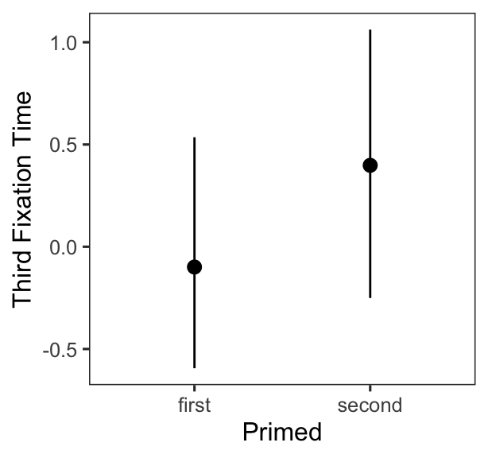

Ok that’s weird…. we predict the opposite effect.

This could be a selection confound. We are picking out trials where there are at least four fixations. For the first-primed group, this means the person looked at the primed cue for a second time but still couldn’t remember it and switched back to the second cue. Perhaps this only happens when the memory for the first cue is *really* weak. Given that we know memory strength predicts third fixation duration, it makes sense that trials which are (inadvertently) selected to have weak first-cue memory strength will have shorter third fixations.

Controlling for the strength of the first cue, the negative effect of the prime all but disappears. Note that our memory strength measure is noisy, so even controlling for this, we can still be selecting for cues that are actually not remembered well despite what our measure says (roughly, we are selecting for the residual errror in the strength measure). We also see that low first-cue strengths are more common when the first cue is primed (consistent with my explanation). Note: these are fixed effects because we can’t fit the full mixed model.

```r
human %>%
    filter(n_pres >= 4) %>%
    mutate(first_primed = int(first_primed)) %>%
    lm(third_pres_time ~ first_primed * strength_first, data=.) %>%
    summ
```

|  | Est. | S.E. | t val. | p |
| --- | --- | --- | --- | --- |
| (Intercept) | 0.175 | 0.318 | 0.552 | 0.585 |
| first_primed | -0.133 | 0.554 | -0.240 | 0.812 |
| strength_first | 1.091 | 0.452 | 2.414 | 0.022 |
| first_primed:strength_first | -0.923 | 0.582 | -1.584 | 0.124 |

Standard errors: OLS

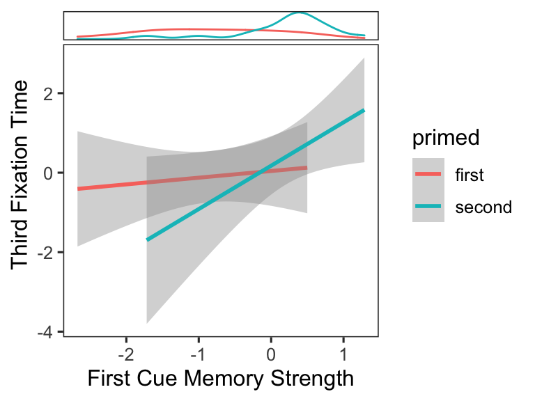

```r
human %>%
    filter(n_pres >= 4) %>%
    ggplot(aes(strength_first, third_pres_time, color=primed)) +
    geom_smooth(method='lm') +
    geom_xdensity + theme(legend.position="right") +
    labs(x=pretty_name("strength_first"), y=pretty_name("third_pres_time"))
```

# More interactions

For completeness, here are all the main memory strength effects from Experiment 1, adding an interaction with the prime. The simple ones look very reasonable. The fixation durations are all really noisy, so I’m not going to interpret them.

## Choice

|  | Est. | S.E. | t val. | p |
| --- | --- | --- | --- | --- |
| (Intercept) | 0.447 | 0.031 | 14.250 | 0.000 |
| strength_first | 0.110 | 0.034 | 3.199 | 0.001 |
| first_primed | 0.376 | 0.043 | 8.682 | 0.000 |
| strength_first:first_primed | -0.009 | 0.046 | -0.204 | 0.838 |

Standard errors: OLS

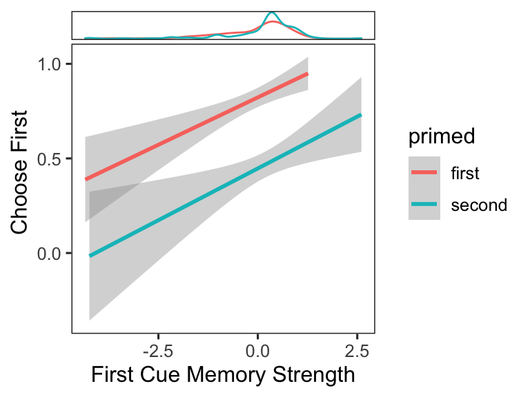

```r
prime_interaction = function(data, xvar, yvar) {
    y = ensym(yvar)
    x = ensym(xvar)
    data %>%
        mutate(first_primed = int(first_primed)) %>%
        lm(inject(!!y ~ !!x * first_primed), data=.) %>%
        summ %>% smart_print
    data %>%
        ggplot(aes({{xvar}}, {{yvar}}, color=primed)) +
        geom_smooth(method='lm') +
        labs(x=pretty_name(x), y=pretty_name(y)) +
        geom_xdensity +
        theme(legend.position="right")
}

human %>%
    filter(n_pres > 0) %>%
    mutate(choose_first = int(choose_first)) %>%
    prime_interaction(strength_first, choose_first)
```

## Overall fixation proportion

```r
human %>%
    filter(n_pres > 0) %>%
    mutate(choose_first = int(choose_first)) %>%
    prime_interaction(rel_strength, prop_first)
```

|  | Est. | S.E. | t val. | p |
| --- | --- | --- | --- | --- |
| (Intercept) | 0.573 | 0.021 | 27.848 | 0.000 |
| rel_strength | 0.028 | 0.015 | 1.924 | 0.055 |
| first_primed | 0.144 | 0.028 | 5.067 | 0.000 |
| rel_strength:first_primed | 0.009 | 0.020 | 0.429 | 0.668 |

Standard errors: OLS

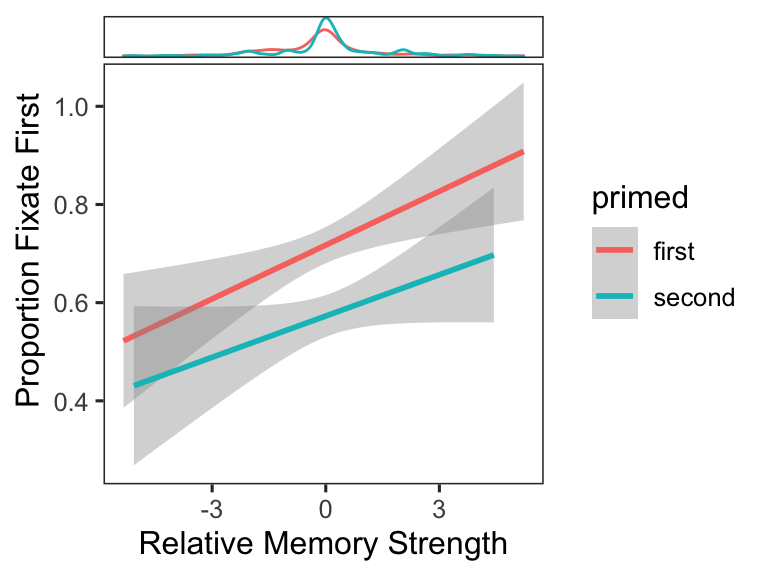

## First fixation

```r
human %>%
    filter(n_pres >= 2) %>%
    prime_interaction(strength_first, first_pres_time)
```

|  | Est. | S.E. | t val. | p |
| --- | --- | --- | --- | --- |
| (Intercept) | -0.172 | 0.062 | -2.751 | 0.006 |
| strength_first | -0.112 | 0.064 | -1.756 | 0.080 |
| first_primed | -0.057 | 0.091 | -0.624 | 0.533 |
| strength_first:first_primed | 0.086 | 0.089 | 0.962 | 0.337 |

Standard errors: OLS

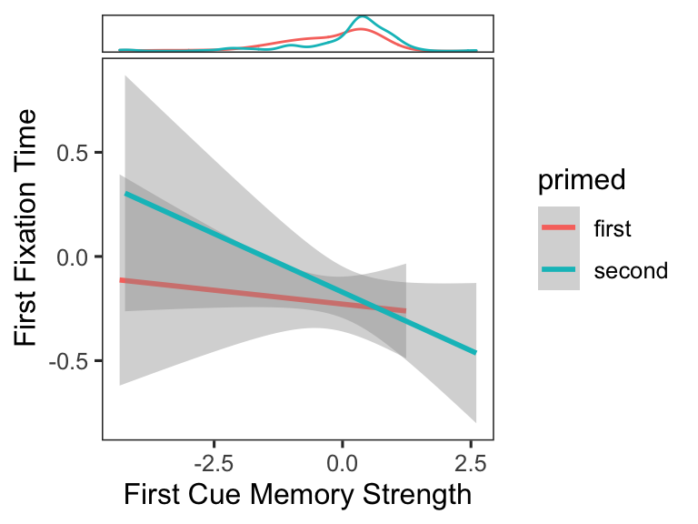

## Second fixation

```r
human %>%
    filter(n_pres >= 3) %>%
    prime_interaction(rel_strength, second_pres_time)
```

|  | Est. | S.E. | t val. | p |
| --- | --- | --- | --- | --- |
| (Intercept) | 0.379 | 0.166 | 2.286 | 0.024 |
| rel_strength | 0.184 | 0.132 | 1.398 | 0.164 |
| first_primed | -0.163 | 0.203 | -0.803 | 0.424 |
| rel_strength:first_primed | -0.168 | 0.152 | -1.107 | 0.270 |

Standard errors: OLS

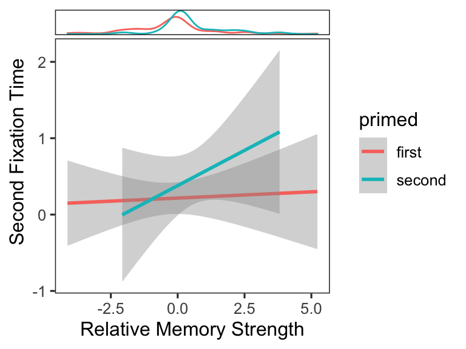

## Third fixation

```r
human %>%
    filter(n_pres >= 4) %>%
    prime_interaction(rel_strength, third_pres_time)
```

|  | Est. | S.E. | t val. | p |
| --- | --- | --- | --- | --- |
| (Intercept) | 0.345 | 0.325 | 1.061 | 0.297 |
| rel_strength | 0.248 | 0.251 | 0.989 | 0.331 |
| first_primed | -0.120 | 0.543 | -0.221 | 0.826 |
| rel_strength:first_primed | 0.259 | 0.475 | 0.544 | 0.590 |

Standard errors: OLS

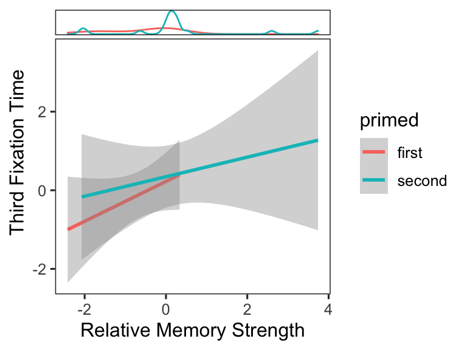

# Miscellaneous

## Response types

We see a similar accuracy rate to Experiment 1.

```r
raw_df %>%
    with((proportions(table(name, response_type), margin=1))) %>%
    kable(digits=2)
```

|  | correct | intrusion | other | timeout | empty |
| --- | --- | --- | --- | --- | --- |
| Optimal | 0.96 | 0.00 | 0.00 | 0.04 | 0 |
| Human | 0.89 | 0.06 | 0.01 | 0.04 | 0 |
| Random | 0.97 | 0.00 | 0.00 | 0.03 | 0 |

## Reaction time

Similar as well.

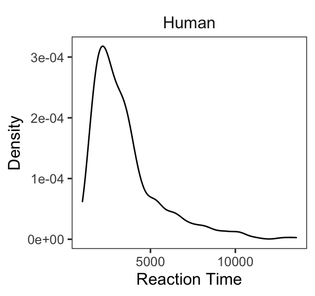

```r
human %>%
    ggplot(aes(rt)) +
    geom_density() +
    facet_grid(~name) +
    labs(x="Reaction Time", y="Density")
```

## Number of fixations

Similar.

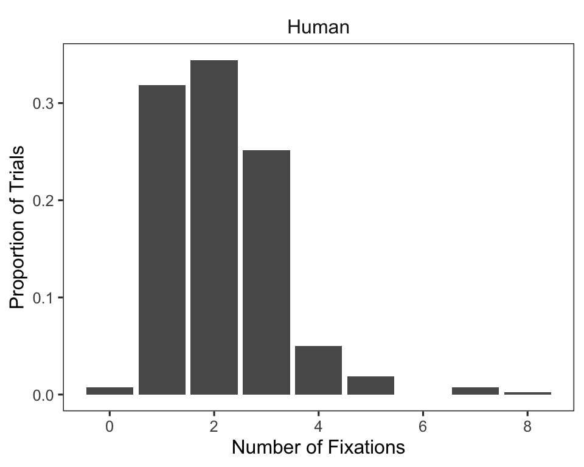

```r
human %>%
    filter(n_pres < 10) %>%
    ggplot(aes(n_pres, ..prop..)) +
    geom_bar() +
    facet_grid(~name) +
    labs(x="Number of Fixations", y="Proportion of Trials")
```